# Project 6 UnSupervised Learning

## EDA

### Univariate analysis

#### Creating histogram and barplot for every numerical field

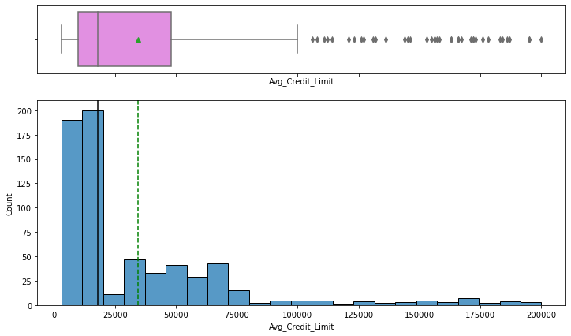

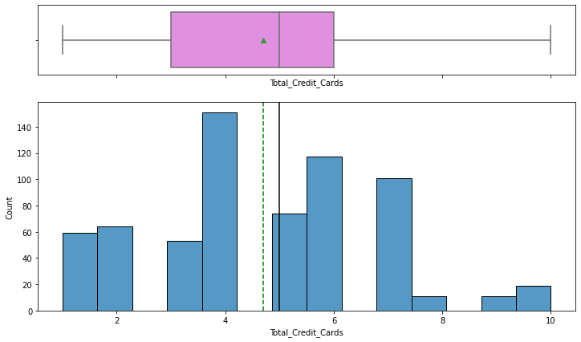

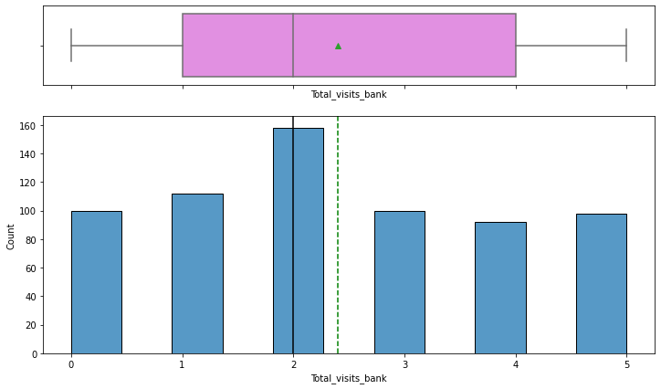

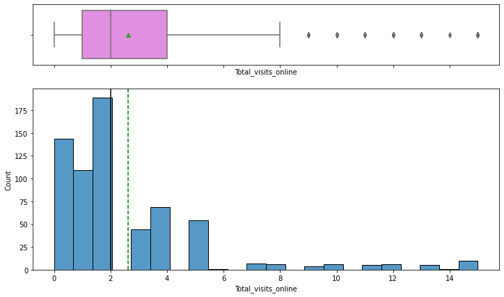

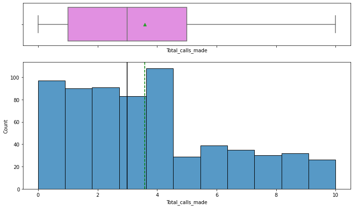

```python
# For every column in the dataframe that has a numerical datatype, show histogram and box plot
for colname in df.columns[df.dtypes == "int64"] | df.columns[df.dtypes == "float64"]:
    histogram_boxplot(df, colname)
```

### Cumulative Distribution Function - CDF

```python
# All the columns in this dataset are numeric, however we are still running this code to select numeric columns
# to ensure that only numerical columns are selected for analysis and if there are any non numeric columns
# they are not included
num_col = df.select_dtypes(include=np.number).columns.tolist()
```

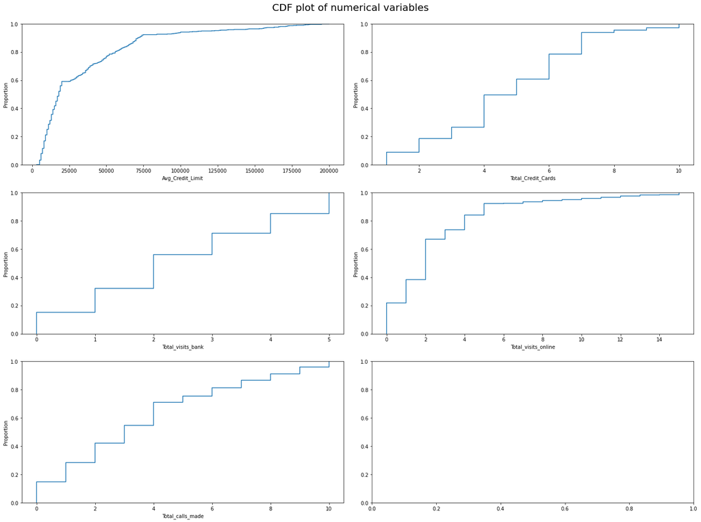

```python
fig, axes = plt.subplots(3, 2, figsize=(20, 15))
fig.suptitle("CDF plot of numerical variables", fontsize=20)
counter = 0
for ii in range(3):
    sns.ecdfplot(ax=axes[ii][0], x=df[num_col[counter]])
    counter = counter + 1
    if counter != 5:
        sns.ecdfplot(ax=axes[ii][1], x=df[num_col[counter]])
        counter = counter + 1
    else:
        pass

fig.tight_layout(pad=2.0)
```

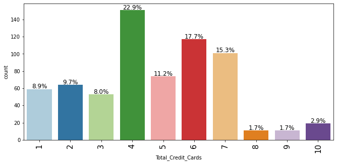

```python
# let's explore total_credit_cards further
labeled_barplot(df, "Total_Credit_Cards", perc=True)
```

The most common number of credit cards is 4 with 22.9% of the customers, then 6 with 17.7%, then 7 with 15.3%. 2.9% have 10 credit cards. The least common are 8 and 9 total credit cards with only 1.7%.

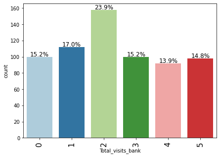

```python
# let's explore Total_visits_bank further
labeled_barplot(df, "Total_visits_bank", perc=True)
```

The highest number of visits is 2 with 23.9 % of the customers. 14% to 17% of the customers visted the bank from 0 to 5 times.

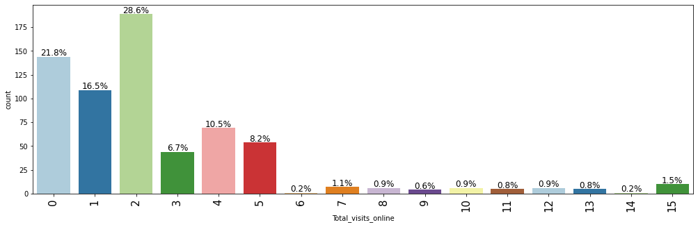

```python
# let's explore Total_visits_online further
labeled_barplot(df, "Total_visits_online", perc=True)
```

28.6% of the customers visited the bank online 2 times. 21.8 % visited 0 times and 16.5% visisted the bank online only 1 time. The customers are not having much online activity, the business can look into this to see if the online experience can be made better.

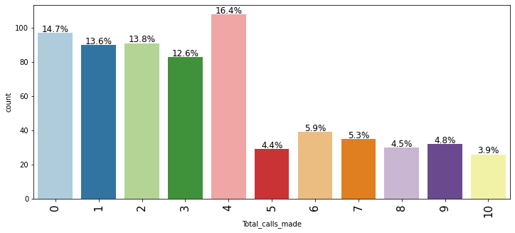

```python
# let's explore Total_calls_made further
labeled_barplot(df, "Total_calls_made", perc=True)
```

The most common total_calls_made is 4 at 16.4%. Around 13% to 15% of the customers called 0 to 3 times. The customers who called more than 4 times is less than 6%. There are 4% of the customers who called 10 times.

## Bivariate analysis

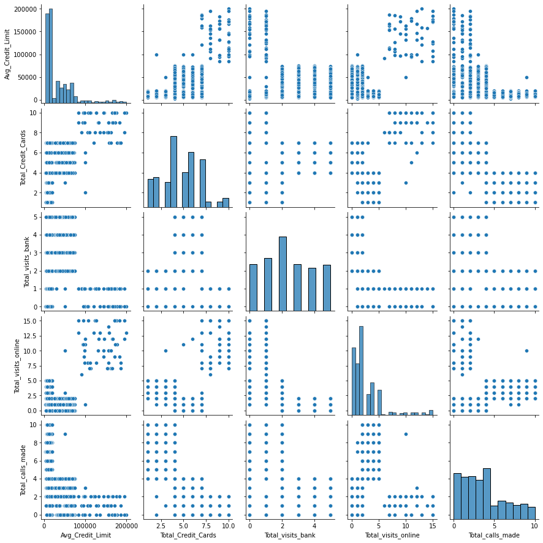

```python
sns.pairplot(data=df)
```

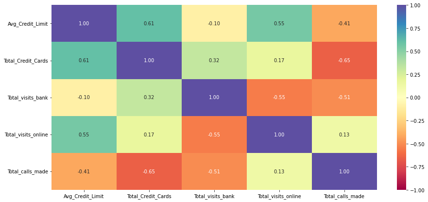

```python
correlation = df.corr()
plt.figure(figsize=(15, 7))
sns.heatmap(correlation, annot=True, vmin=-1, vmax=1, fmt=".2f", cmap="Spectral")
plt.show()
```

1. Avg_Credit_Limit is highly positively correlated to Total_Credit_Cards and Total_visits_online. As the avg_credit_limit increases then the total_credit_cards and Total_Visits_online also increases. THis is reasonable since the number of cards can increase the credit limit and also will increase the online visits as have to deal with more cards.
2. Total_Credit_Cards is negatively correlated to the total_Calls_made.
3. Total_Visits_bank is negatively correlated with total_visits_online and total_Calls_made. This is reasonable since personally going to the bank should result in fewer online visits and phone calls to the bank.
4. Total_calls_made is negatively corelated to avg_credit_limit, total_credit_cards, and total_visits_bank. If a person made a high number of total_calls then he/she will probably have a lower avg_credit_limit, a lower number of total_credit_Cards and lower number of visits to the bank. This is also reasonable.

## Outlier Treatment

There are outliers in the data, especially avg_credit_limit has extreme upper outliers. However, all the outliers are natural and therefore will not be treated. We can look at Manhattan distance as it deals better with outliers as compared to Euclidean distance.

## Data Preprocessing

```python
# variables used for clustering
num_col
```

```
['Avg_Credit_Limit',
 'Total_Credit_Cards',
 'Total_visits_bank',
 'Total_visits_online',
 'Total_calls_made']
```

```python
# scaling the dataset before clustering
scaler = StandardScaler()
subset = df[num_col].copy()
subset_scaled = scaler.fit_transform(subset)
# storing the scaled data in X dataframe for use later
X = pd.DataFrame(scaler.fit_transform(subset))
```

```python
# creating a dataframe of the scaled columns
subset_scaled_df = pd.DataFrame(subset_scaled, columns=subset.columns)
```

## K-means Clustering

```
Number of Clusters: 1 	Average Distortion: 2.0069222262503614
Number of Clusters: 2 	Average Distortion: 1.4571553548514269
Number of Clusters: 3 	Average Distortion: 1.1466276549150365
Number of Clusters: 4 	Average Distortion: 1.0463825294774465
Number of Clusters: 5 	Average Distortion: 0.9907072114489897
Number of Clusters: 6 	Average Distortion: 0.9430905743841549
Number of Clusters: 7 	Average Distortion: 0.9094735106226701
Number of Clusters: 8 	Average Distortion: 0.8892651271072852
```

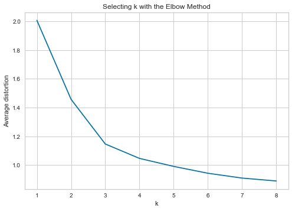

```python
clusters = range(1, 9)
meanDistortions = []

for k in clusters:
    model = KMeans(n_clusters=k)
    model.fit(subset_scaled_df)
    prediction = model.predict(subset_scaled_df)
    distortion = (
        sum(
            np.min(cdist(subset_scaled_df, model.cluster_centers_, "euclidean"), axis=1)
        )
        / subset_scaled_df.shape[0]
    )

    meanDistortions.append(distortion)

    print("Number of Clusters:", k, "\tAverage Distortion:", distortion)

plt.plot(clusters, meanDistortions, "bx-")
plt.xlabel("k")
plt.ylabel("Average distortion")
plt.title("Selecting k with the Elbow Method")
plt.show()
```

```
Number of Clusters: 1 	Average Distortion: 2.0069222262503614
Number of Clusters: 2 	Average Distortion: 1.4571553548514269
Number of Clusters: 3 	Average Distortion: 1.1466276549150365
Number of Clusters: 4 	Average Distortion: 1.0463825294774465
Number of Clusters: 5 	Average Distortion: 0.9908683849620168
Number of Clusters: 6 	Average Distortion: 0.9430843103448057
Number of Clusters: 7 	Average Distortion: 0.9094989512081387
Number of Clusters: 8 	Average Distortion: 0.8868556126926921
```

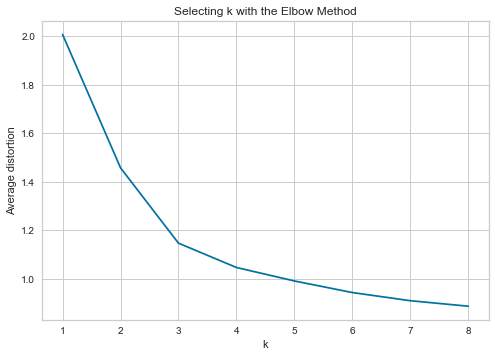

```python
clusters = range(1, 9)
meanDistortions = []

for k in clusters:
    model = KMeans(n_clusters=k)
    model.fit(subset_scaled_df)
    prediction = model.predict(subset_scaled_df)
    distortion = (
        sum(
            np.min(cdist(subset_scaled_df, model.cluster_centers_, "euclidean"), axis=1)
        )
        / subset_scaled_df.shape[0]
    )

    meanDistortions.append(distortion)

    print("Number of Clusters:", k, "\tAverage Distortion:", distortion)

plt.plot(clusters, meanDistortions, "bx-")
plt.xlabel("k")
plt.ylabel("Average distortion")
plt.title("Selecting k with the Elbow Method")
plt.show()
```

Appropriate value for k seems to be 3 or 4.

#### Let's check the silhouette scores.

```
For n_clusters = 2, the silhouette score is 0.41842496663215445)
For n_clusters = 3, the silhouette score is 0.5157182558881063)
For n_clusters = 4, the silhouette score is 0.3556670619372605)
For n_clusters = 5, the silhouette score is 0.2717470361089752)
For n_clusters = 6, the silhouette score is 0.255906765297388)
For n_clusters = 7, the silhouette score is 0.24846460500119677)
For n_clusters = 8, the silhouette score is 0.22836524244629758)
For n_clusters = 9, the silhouette score is 0.21838569885199205)
```

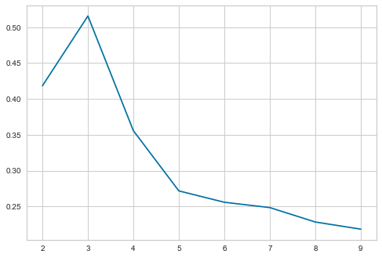

```python
sil_score = []
cluster_list = list(range(2, 10))
for n_clusters in cluster_list:
    clusterer = KMeans(n_clusters=n_clusters)
    preds = clusterer.fit_predict((subset_scaled_df))
    # centers = clusterer.cluster_centers_
    score = silhouette_score(subset_scaled_df, preds)
    sil_score.append(score)
    print("For n_clusters = {}, the silhouette score is {})".format(n_clusters, score))

plt.plot(cluster_list, sil_score)
plt.show()
```

Silhouette score for 3 is higher than that for 4. So, we will choose 3 as value of k.

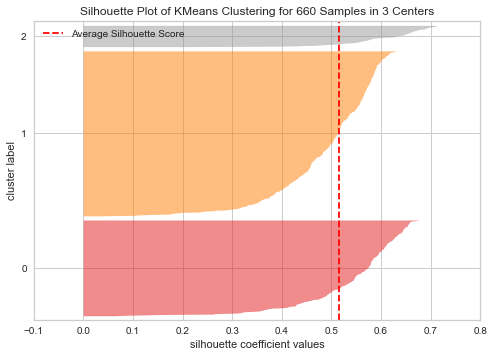

```python
# finding optimal no. of clusters with silhouette coefficients
visualizer = SilhouetteVisualizer(KMeans(3, random_state=1))
visualizer.fit(subset_scaled_df)
visualizer.show()
```

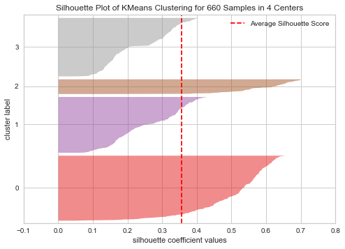

```python
# finding optimal no. of clusters with silhouette coefficients
visualizer = SilhouetteVisualizer(KMeans(4, random_state=1))
visualizer.fit(subset_scaled_df)
visualizer.show()
```

```python
# let's take 3 as number of clusters
kmeans = KMeans(n_clusters=3, random_state=0)
kmeans.fit(subset_scaled_df)
```

```
KMeans(n_clusters=3, random_state=0)
```

```python
# adding kmeans cluster labels to the original and scaled dataframes

df["K_means_segments"] = kmeans.labels_
subset_scaled_df["K_means_segments"] = kmeans.labels_
```

## Cluster Profiling

```python
cluster_profile = df.groupby("K_means_segments").mean()
```

```python
cluster_profile["count_in_each_segments"] = (
    df.groupby("K_means_segments")["Avg_Credit_Limit"].count().values
)
```

```python
# let's display cluster profiles
cluster_profile.style.highlight_max(color="lightgreen", axis=0)
```

| K_means_segments | Avg_Credit_Limit | Total_Credit_Cards | Total_visits_bank | Total_visits_online | Total_calls_made | count_in_each_segments |
| --- | --- | --- | --- | --- | --- | --- |
| 0 | 33782.383420 | 5.515544 | 3.489637 | 0.981865 | 2.000000 | 386 |
| 1 | 12174.107143 | 2.410714 | 0.933036 | 3.553571 | 6.870536 | 224 |
| 2 | 141040.000000 | 8.740000 | 0.600000 | 10.900000 | 1.080000 | 50 |

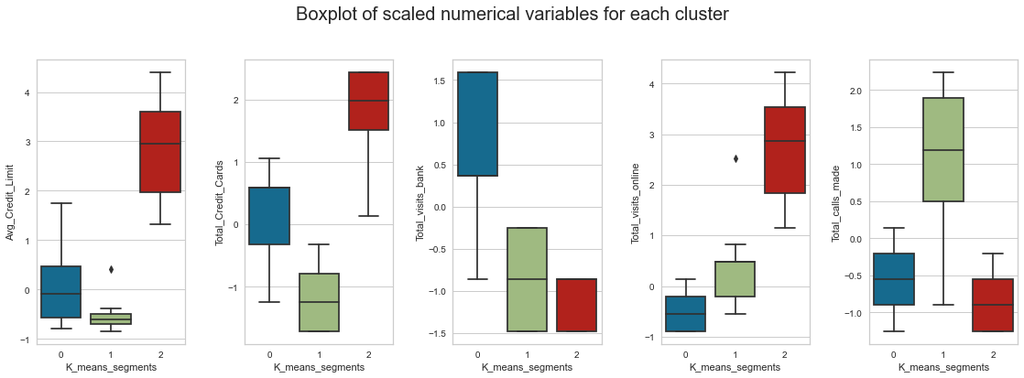

```python
fig, axes = plt.subplots(1, 5, figsize=(16, 6))
fig.suptitle("Boxplot of scaled numerical variables for each cluster", fontsize=20)
counter = 0
for ii in range(5):
    sns.boxplot(
        ax=axes[ii],
        y=subset_scaled_df[num_col[counter]],
        x=subset_scaled_df["K_means_segments"],
    )
    counter = counter + 1

fig.tight_layout(pad=2.0)
```

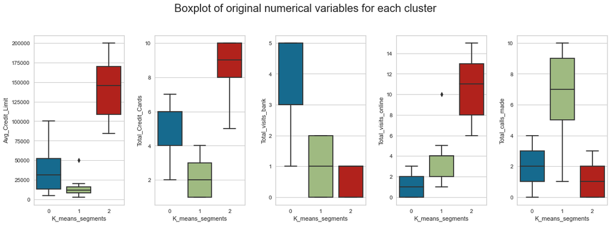

```python
fig, axes = plt.subplots(1, 5, figsize=(16, 6))
fig.suptitle("Boxplot of original numerical variables for each cluster", fontsize=20)
counter = 0
for ii in range(5):
    sns.boxplot(ax=axes[ii], y=df[num_col[counter]], x=df["K_means_segments"])
    counter = counter + 1

fig.tight_layout(pad=2.0)
```

## Insights

### Cluster 2

- Customers in this cluster have really high credit limits, with a median just below 150,000. This cluster also has the highest number of credit cards. It has the lowest number of vists to the bank. This cluster also has the highest online activity with the central range from 8 to 13. This cluster also has the lowest number of calls made, witha median of 1 for total_calls_made.